# HW6_20203374_이호용

## 1 - (1)

## 1.Load data and fit the model

```r
rm(list=ls())
load('C:/Users/Hoyong/Downloads/RABE5.RData')
df <- P198 ; #head(df)
lm <- lm(Y ~ X1 + X2 + X3, data=df)
#summary(lm) # I've checked the result but hide result for simplicity
```

Except X3 coef, other coefficients are significant. And the model is significant.

### 2. Checking leverage, Influential, Outliers.

```r
p <- length(lm$coefficients)-1 ; n <- dim(df)[1]
lev <- influence(lm)$hat
reference_value <- 2*(p+1)/n
```

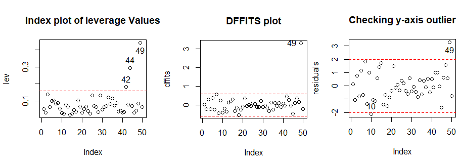

```r
plot(lev, main='Index plot of leverage Values') # Calculate high leverage and plot lines.
abline(h = reference_value, lty=2, col = 'red')
identify(lev)

dffits <- dffits(lm) # Using DFFITS to find influential points.
ref <- 2*sqrt((p+1)/(n-p-1))
plot(dffits, main='DFFITS plot')
abline(h= c(-ref,ref), col='red', lty=2)
identify(dffits)

residuals <- rstandard(lm) # Checking y-axis outliers w/ residual plot
plot(residuals, main='Checking y-axis outlier')
abline(h=c(-2,2), col='red', lty=2)
identify(residuals)
```

*As we can see, (42, 44, 49) are leverage points (X-axis outliers).*

*Influential = 49th point.*

*Outliers = (10, 49) points(Y-axis outliers).*

## 1 - (2)

### Checking Residual plots

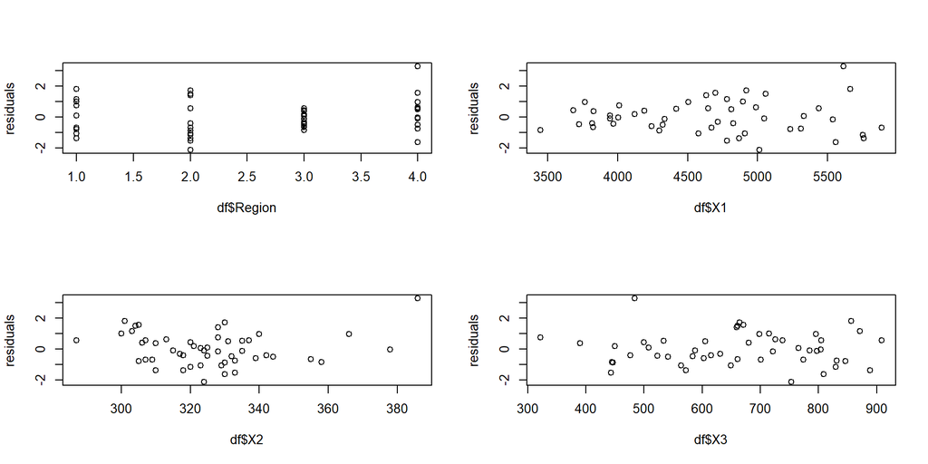

```r
residuals <- rstandard(lm)
par(mfrow=c(2,2))
plot(df$Region, residuals); plot(df$X1, residuals);
plot(df$X2, residuals); plot(df$X3, residuals)
```

*In 1st plot compare with other Regions, Region3 shows kind of heteroskedasticity. And 2nd plot (*$X_1$*,*$r_i$*) shows heteroskedasticity too.*

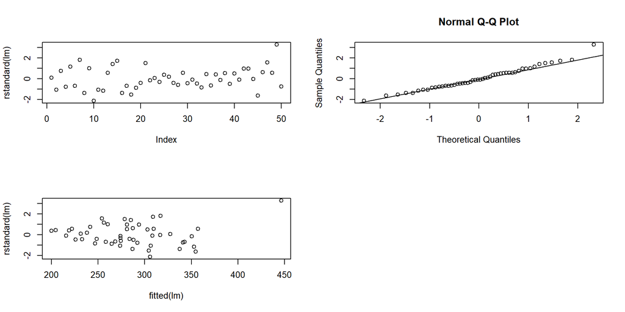

```r
par(mfrow=c(2,2))
plot(rstandard(lm)) ; qqnorm(rstandard(lm)) ; qqline(rstandard(lm))
plot(fitted(lm), rstandard(lm))
```

*(*$\hat{y_i}$*,*$r_i$*) plot shows obvious heteroskedasticity.*

And 49th point was influential and high leverage, I’ll check dropped 49th point model and check If there’s any difference.

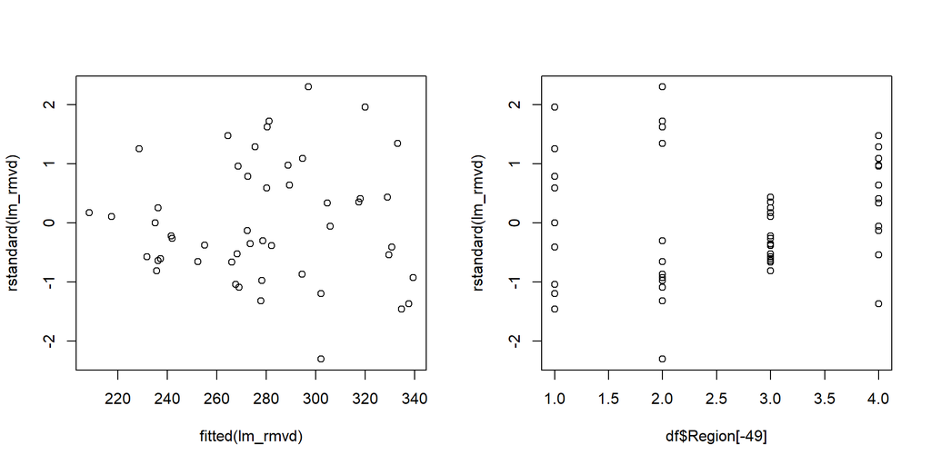

```r
lm_rmvd <- lm(lm, subset=-c(49))
par(mfrow=c(1,2))
plot(fitted(lm_rmvd), rstandard(lm_rmvd))
plot(df$Region[-49], rstandard(lm_rmvd))
```

After removing 49th point, above plot still shows heteroskedasticity.

*To solve heteroskedasticity problem, we may consider transformation or fit the WLS models.*

## 1 - (3)

### 1.Fit the model (WLS model with two-stage estimation)

```r
df_new <- df[-c(44, 49),] # removing (44,49)th observations.
lm_rmvd <- lm(Y ~ X1+X2+X3, data=df_new)
table(df$Region) ; table(df_new$Region)
```

```
##
##  1  2  3  4
##  9 12 16 13
```

```
##
##  1  2  3  4
##  9 12 16 11
```

```r
df[c(44, 49), ]
```

```
##        Y   X1  X2  X3 Region
## UT   315 4005 378 804      4
## AK   546 5613 386 484      4
```

We have to estimate $C^2_j$, I know the direct coding is efficient, but to reuse later,

I defined a function that calculate $\hat{\sigma_j^2}$ and weights

### 2. Define function to calculate $\hat{\sigma_j^2}$

```r
list = c('1', '2', '3', '4')
s_list <- c('s1', 's2', 's3', 's4')
residuals <- lm_rmvd$residuals

calc_sigma_j_sq <- function(x){
  value_count <- length(which(df_new$Region==list[x])) # Calculate length of each groups
  result <- sum(residuals[(df_new$Region==x)]^2)/(value_count-1) # Calculate sigma_j^2_hat
  return(result)
}
```

### 3. Calculate weights

```r
for(i in 1:4){
  assign(paste0('s',1:4)[i], calc_sigma_j_sq(i))
  # Make(s1,s2,s3,s4) and assign sigma_j^2 values sequentially
  df_new$w[df_new$Region==i] <- 1/get(s_list[i])
  # Calculate Weights and assign them to new rows
}
```

```r
c(s1,s2,s3,s4)
```

```
## [1] 1614.8318 2669.2897  245.9945 1157.9857
```

### 4. Fitting weighted model

```r
weighted_model <- lm(Y ~ X1+X2+X3, data=df_new, weight=w)
residuals <- rstandard(weighted_model)
summary(weighted_model)
```

```
##
## Call:
## lm(formula = Y ~ X1 + X2 + X3, data = df_new, weights = w)
##
## Weighted Residuals:
##      Min       1Q   Median       3Q      Max
## -1.54864 -0.68775 -0.01286  0.73171  1.86814
##
## Coefficients:
##               Estimate Std. Error t value Pr(>|t|)
## (Intercept) -2.933e+02  7.738e+01  -3.791 0.000453 ***
## X1           6.432e-02  7.596e-03   8.468 8.67e-11 ***
## X2           8.004e-01  2.010e-01   3.983 0.000252 ***
## X3           1.679e-02  3.394e-02   0.495 0.623151
## ---
## Signif. codes:  0 '***' 0.001 '**' 0.01 '*' 0.05 '.' 0.1 ' ' 1
##
## Residual standard error: 0.9298 on 44 degrees of freedom
## Multiple R-squared:  0.7746, Adjusted R-squared:  0.7592
## F-statistic: 50.41 on 3 and 44 DF,  p-value: 2.772e-14
```

Summary of the model shows every coefficients except X3 are significant. And the model is also significant. $R^2$ = 0.7746, acceptable.

Let’s check if the previous heteroskedasticity problem is solved.

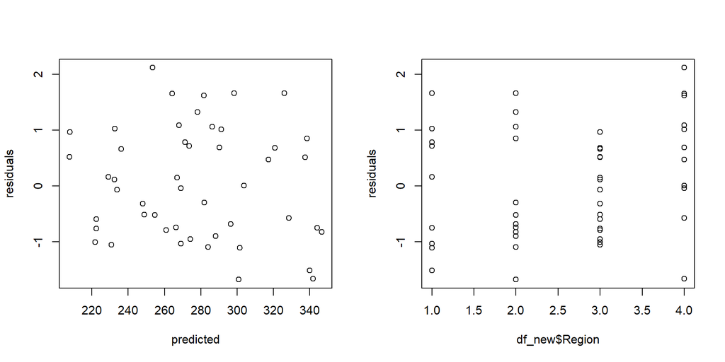

```r
predicted <- fitted(weighted_model)
residuals <- rstandard(weighted_model)
par(mfrow=c(1,2))
plot(predicted, residuals) ; plot(df_new$Region, residuals)
```

As we can from the plot above, heteroskedasticity problem got better.

Let’s compare previous model with WLS model.

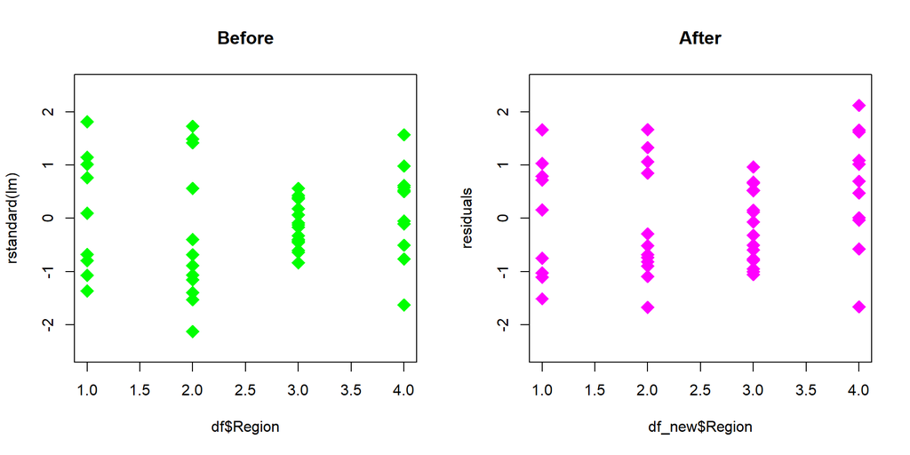

```r
par(mfrow=c(1,2))
plot(df$Region, rstandard(lm), ylim=c(-2.5,2.5), col='green', pch=18, cex=2, main = 'Before')
plot(df_new$Region, residuals, ylim=c(-2.5,2.5), col='magenta', pch=18, cex=2, main = 'After')
```

*As we can see above, After model(WLS) got better.*

## Table I

Calculate $\hat{\sigma^2}$ and make the table below.

```r
table(df_new$Region)
```

```
##
##  1  2  3  4
##  9 12 16 11
```

```r
Region_j <- c('Northeast', 'North Central', 'South', 'West') # Define initial vectors
nj <- c(9, 12, 16, 11)
sigma_j_squared <- c(s1, s2, s3, s4)

# calculate sigma_squared_hat
result <- 0 # set the initial value as 0
for (i in 1:4){
    result <- c(result, (length(which(df_new$Region==list[i]))-1)*get(s_list[i]))
} # loop 1:4 to append result vectors with {(nj-1)*sigma_h_squared}
sigma_squared_hat <- sum(result[-1]/length(df_new$Region))
# sigma_squared_hat = sum(above result) devided with sum(nj)

c_j_squared <- (sigma_j_squared/sigma_squared_hat) # Estimate C_j^2
c_j_squared
```

```
## [1] 1.3468479 2.2263168 0.2051714 0.9658162
```

```r
cj <- sqrt(sigma_j_squared/sigma_squared_hat)
table_1 <- cbind(Region_j, nj, sigma_j_squared, cj)
knitr::kable(table_1)
```

| Region_j | nj | sigma_j_squared | cj |
| --- | --- | --- | --- |
| Northeast | 9 | 1614.83180626409 | 1.16053776159951 |
| North Central | 12 | 2669.28966677159 | 1.49208471449744 |
| South | 16 | 245.994548750033 | 0.452958454599842 |
| West | 11 | 1157.9857445901 | 0.982759464961009 |

## Table Ⅱ

OLS and WLS Coefficients

|  | OLS |  |  | WLS |  |  |
| --- | --- | --- | --- | --- | --- | --- |
| Variable | Coefficient | s.e. | t | Coefficient | s.e. | t |
| Constant | -260.61392909 | 142.86916 | -1.824 | -2.933e+02 | 7.738e+01 | -3.791 |
| $X_1$ | 0.04905006 | 0.01247 | 3.933 | 6.432e-02 | 7.596e-03 | 8.468 |
| $X_2$ | 0.83484434 | 0.36830 | 2.267 | 8.004e-01 | 2.010e-01 | 3.983 |
| $X_3$ | 0.06092010 | 0.05278 | 1.154 | 1.679e-02 | 3.394e-02 | 0.495 |
|  | $R^2=.4922$ | $\hat{\sigma}=36.17$ |  | $R^2=.7746$ | $\hat{\sigma} = 0.9298$ |  |

We can check above results with summary(lm_rmvd), summary(weighted_model).

## 1 - (4)

To make homogeneous variance structure, If we divide ${\sigma}_{ij}^2$ with $x^2_{ij1}$, Var($\epsilon*_{ij}$)=${\sigma^2}_{ij^/x^2_{ij1}}$ = $k^2$.  
Then we can define weights as w = $1/x^2_{ij1}$

### 1. Define weights and fit the model

```r
w <- 1/df$X1^2
lm_w <- lm(Y ~ X1+ X2 + X3, data=df, weight=w)
summary(lm_w)
```

```
##
## Call:
## lm(formula = Y ~ X1 + X2 + X3, data = df, weights = w)
##
## Weighted Residuals:
##       Min        1Q    Median        3Q       Max
## -0.017165 -0.005883 -0.001093  0.004541  0.019681
##
## Coefficients:
##               Estimate Std. Error t value Pr(>|t|)
## (Intercept) -520.58663  115.40074  -4.511 4.44e-05 ***
## X1             0.07069    0.01113   6.351 8.61e-08 ***
## X2             1.43528    0.28875   4.971 9.70e-06 ***
## X3             0.01104    0.04626   0.239    0.812
## ---
## Signif. codes:  0 '***' 0.001 '**' 0.01 '*' 0.05 '.' 0.1 ' ' 1
##
## Residual standard error: 0.008186 on 46 degrees of freedom
## Multiple R-squared:  0.6038, Adjusted R-squared:  0.5779
## F-statistic: 23.36 on 3 and 46 DF,  p-value: 2.452e-09
```

Above table shows that, X3 Coefficient is not significant, other Coefficients are significant. and $R^2_{adj}=0.5779$ is acceptable.

And Regression model is significant. Let’s check if there’s any problem with that model.

### 2. Checking leverage, influential, outliers.

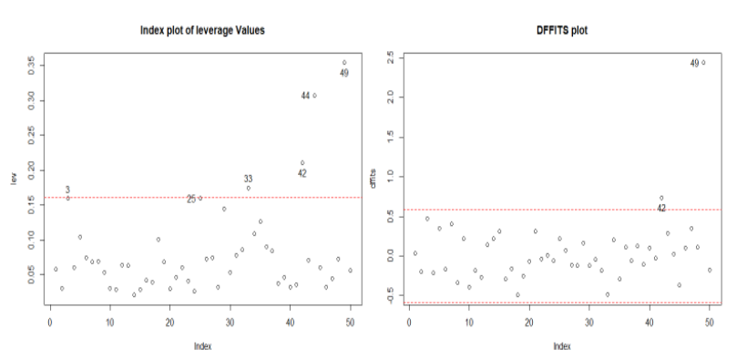

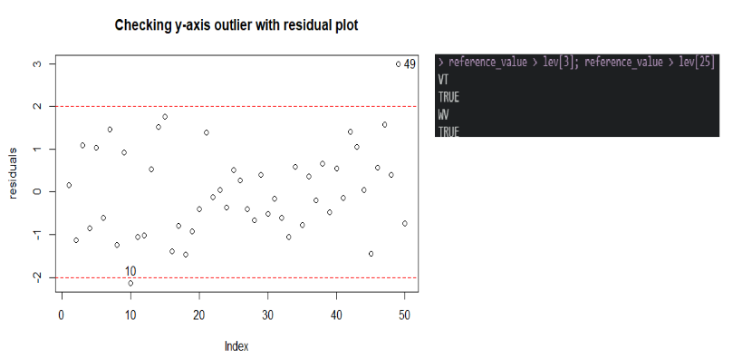

```r
# Leverage
p <- length(lm_w$coefficients)-1 ; n <- dim(df)[1]
lev <- influence(lm_w)$hat
plot(lev, main='Index plot of leverage Values')
reference_value <- 2*(p+1)/n
abline(h = reference_value, lty=2, col = 'red')
identify(lev)

# Influential
dffits <- dffits(lm_w)
plot(dffits, main='DFFITS plot')
ref <- 2*sqrt((p+1)/(n-p-1))
abline(h= c(-ref,ref), col='red', lty=2)
identify(dffits)


# Outlier
residuals <- rstandard(lm_w)
plot(residuals, main='Checking y-axis outlier with residual plot') ; abline(h=c(-2,2), col='red', lty=2)
identify(residuals)
```

As we can see, (33,42,44,49) are leverage points (X-axis outliers).

Influential = (42,49) points.

Outliers = (10, 49)th points (Y-axis outliers).

### 3. Diagnostics

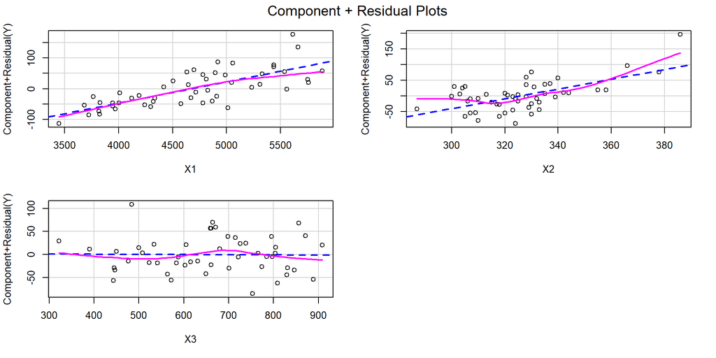

```r
library(car); crPlots(lm_w) # Checking linearity assumptions
```

*Linearity assumptions seems fine.*

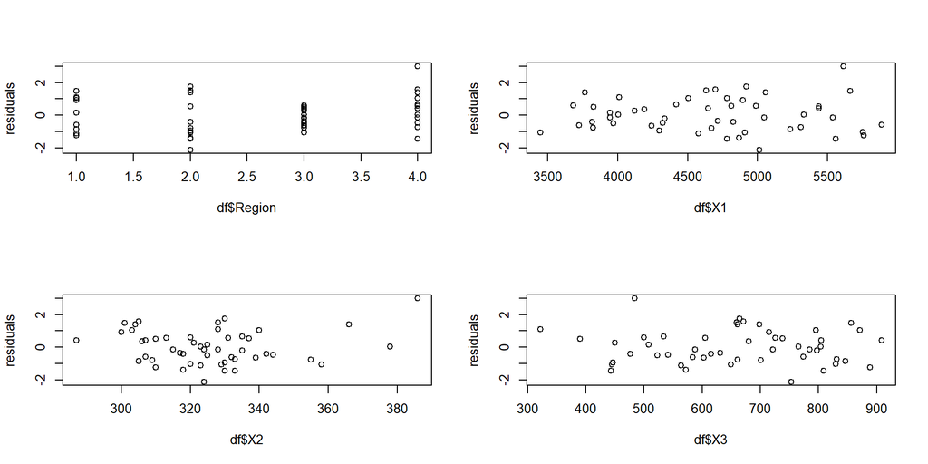

```r
residuals <- rstandard(lm_w) # Checking constant variance assumptions
par(mfrow=c(2,2))
plot(df$Region, residuals); plot(df$X1, residuals)
plot(df$X2, residuals); plot(df$X3, residuals)
```

*1st plot above and (*$X_1$*,*$ri$*) plot shows heteroscedasticity problem.*

Checking normality assumptions.

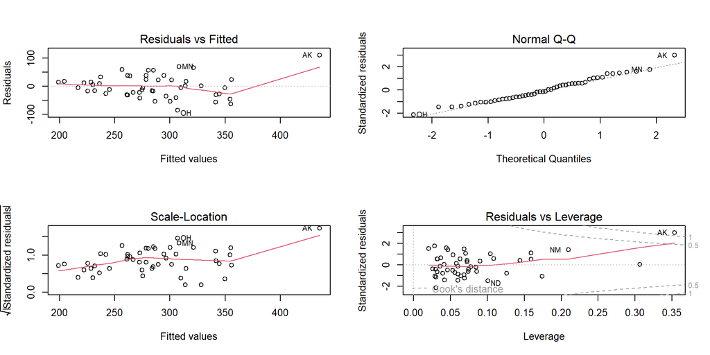

```r
par(mfrow=c(2,2))
plot(lm_w)
```

*Normality assumptions seems fine. and (*$\hat{y_i}$*,* $r_i$*) plots shows heteroscedasticity too.*

```r
durbinWatsonTest(residuals) ; vif(lm_w)
```

```
## [1] 2.117592
```

```
##       X1       X2       X3
## 1.762765 1.145332 1.603448
```

*Independency assumptions seems to be satisfied. It doesn’t looks like have a multicolinearity.*

*So we can conclude, this model has Influential points = (42,49)th points.*

## 1 - (5)

### OLS regression line with interaction

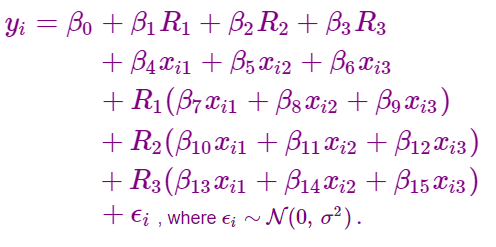

### 1.Make dummy variables

```r
df$Region <- factor(df$Region, levels = c(4,1,2,3)) # Set Region4 as reference variavle.
str(df)
```

```
## 'data.frame':    50 obs. of  5 variables:
##  $ Y     : num  235 231 270 261 300 317 387 285 300 221 ...
##  $ X1    : num  3944 4578 4011 5233 4780 ...
##  $ X2    : num  325 323 328 305 303 307 301 310 300 324 ...
##  $ X3    : num  508 564 322 846 871 774 856 889 715 753 ...
##  $ Region: Factor w/ 4 levels "4","1","2","3": 2 2 2 2 2 2 2 2 2 3 ...
```

I’ve set the reference variable as $Region_4$.

### 2.Fit the model and plot

```r
interaction_lm <- lm(Y ~ X1 + X2 + X3 + X1*Region + X2*Region + X3*Region, data=df)
summary(interaction_lm)
```

```
##
## Call:
## lm(formula = Y ~ X1 + X2 + X3 + X1 * Region + X2 * Region + X3 *
##     Region, data = df)
##
## Residuals:
##     Min      1Q  Median      3Q     Max
## -84.678 -15.774  -2.899  15.758  78.368
##
## Coefficients:
##               Estimate Std. Error t value Pr(>|t|)
## (Intercept) -5.053e+02  2.408e+02  -2.099 0.043335 *
## X1           7.508e-02  2.032e-02   3.696 0.000767 ***
## X2           1.687e+00  4.991e-01   3.380 0.001832 **
## X3          -1.374e-01  9.243e-02  -1.486 0.146480
## Region1      2.009e+03  9.357e+02   2.147 0.039049 *
## Region2     -2.954e+01  4.884e+02  -0.060 0.952129
## Region3      2.095e+02  3.341e+02   0.627 0.534806
## X1:Region1  -3.462e-02  3.936e-02  -0.880 0.385290
## X1:Region2  -3.452e-02  5.299e-02  -0.651 0.519110
## X1:Region3  -3.609e-03  3.186e-02  -0.113 0.910485
## X2:Region1  -5.802e+00  2.640e+00  -2.198 0.034896 *
## X2:Region2  -3.992e-02  1.365e+00  -0.029 0.976842
## X2:Region3  -9.321e-01  7.779e-01  -1.198 0.239115
## X3:Region1  -5.566e-02  1.972e-01  -0.282 0.779507
## X3:Region2   2.749e-01  1.887e-01   1.457 0.154412
## X3:Region3   1.293e-01  1.416e-01   0.913 0.367769
## ---
## Signif. codes:  0 '***' 0.001 '**' 0.01 '*' 0.05 '.' 0.1 ' ' 1
##
## Residual standard error: 39.27 on 34 degrees of freedom
## Multiple R-squared:  0.7156, Adjusted R-squared:  0.5901
## F-statistic: 5.703 on 15 and 34 DF,  p-value: 1.301e-05
```

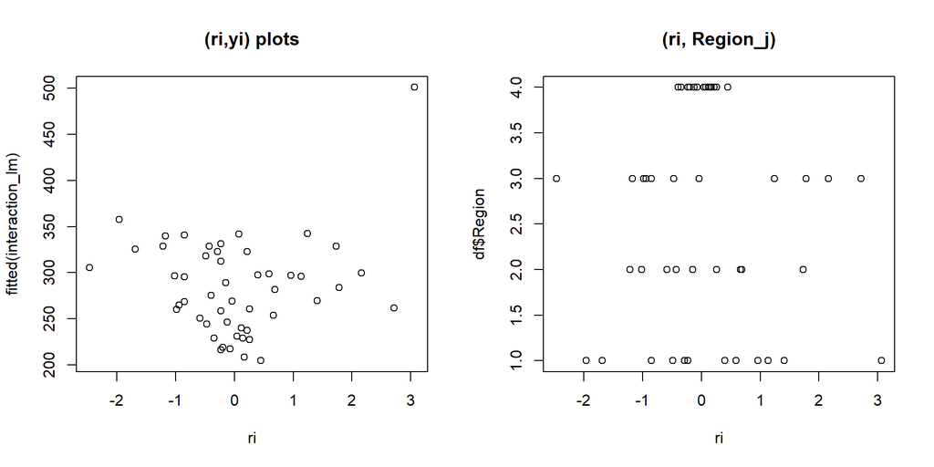

```r
ri <- rstandard(interaction_lm)
par(mfrow=c(1,2))
plot(ri, fitted(interaction_lm), main='(ri,yi) plots')
plot(ri, df$Region, main='(ri, Region_j)')
```

*We can clearly identify there’s heteroscedasticity. (*$r_i$*,* $\hat{y_i}$*) plot shows some kind of funnel shapes. And (*$r_i$*,* $Region_j$*) plot shows heteroscedasticity too.*

**So we can conclude the model is not valid since it violates the homogeneous variance assumption.**